# Peak-calling statistics exercise

Jacques van Helden

2/1/2017

# Tasks

1. **Load** the ChIP-seq coverage profile and the genomic input.
2. Plot the **coverage profiles**.
3. Compute and represent graphically the **distributions of counts per bin**.
4. Compute and draw the **Lorenz curves** for the ChIP-seq data and for the genomic input[^1].
5. **Normalize** the counts per library (ChIP-seq, input) in order to compensate for the different sequencing depths. For this, you need to define a normalizing factor, which will multiply the counts in each sample. As normalizing factor, you can use the *libsum* (sum of read counts per sequencing library), but you might also think about more robust normalization factor, for example the median count, or the $90^{th}$ percentile of the counts per bins.
6. Compute various scores that might be used to **compare the counts** per bin between ChIP-ped and input datasets. For each of the metrics, draw a plot to show the values of the comparison metrics. We might for example think about the following metrics:
   - $d = f_{i,C} - f_{i,G}$, the **difference** between normalized frequencies of the chip ($C$) and genomic input ($G$);
   - $r = \frac{f_{i,C}}{f_{i,G}}$, ChIP_seq / input ratio between normalized counts;
   - $log2FC = log_2(\frac{f_{i,C}}{f_{i,G}})$, the log-fold-change, i.e. the log2(ratio) between normalized frequencies;
   - $LLR = f_{i,G} \cdot ln(\frac{f_{i,C}}{f_{i,G}})$, i.e. background frequency multiplied by the log2(ratio);
   - …
7. Based on the Poisson distribution, compute a **p-value** per bin, as well as an **adjusted p-value** (corrected for multiple testing).
8. Draw a **volcano plot** with the log2-fold-change as measure of the effect size (abscissa) and the $-log_{10}(p_{adj})$ on the ordinate.
9. Select the **significant bins**.
10. **View the results in IGV** and compare the peaks identified with this rudimentary strategy with those returned by a real peak-caller.

# Probabilities

## Poisson density

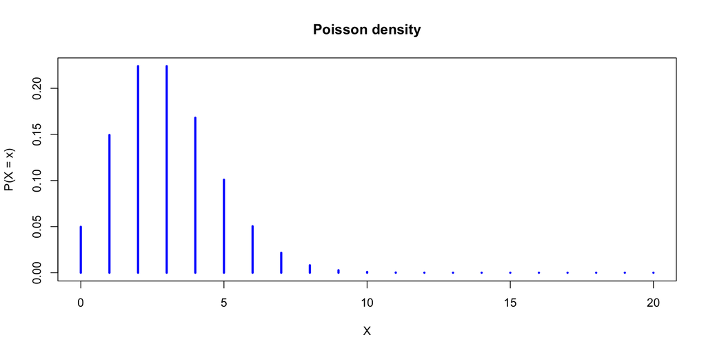

**Poisson density**, with $\lambda = 3$.

```r
x <- 0:20
#print(x)

p <- dpois(x, lambda=3)

plot(x, p, type="h", lwd=3,
     main="Poisson density",
     col="blue",
     xlab="X", ylab="P(X = x)")
```

# Data Loading

```r
## Define the base URL of the course and store it in a variable
url.course <- "http://jvanheld.github.io/stats_avec_RStudio_EBA/"

## Define the fill path of the data directory, by concatenating the course URL and all the successive folders
url.data <- file.path(url.course, "practicals", "02_peak-calling", "data")
```

```r
## Define URL of the ChIP file
chip.bedg.file <- file.path(url.data, "FNR_200bp.bedg")
#print(chip.bedg.file)

## Load the file content in an R data.frame
chip.bedg <- read.table(chip.bedg.file)

## Set column names
names(chip.bedg) <- c("chrom", "start", "end","counts")
```

We loaded the ChIP-seq coverage profile from a bedgraph file[^2]. The file contained 23199 lines corresponding to genomic bins.

```r
## Define URL of the input file
input.bedg.file <- file.path(url.data, "input_200bp.bedg")

## Load the file content in an R data.frame
input.bedg <- read.table(input.bedg.file)

## Set column names
names(input.bedg) <- c("chrom", "start", "end","counts")
```

The background was estimated with a genomic input[^3] containing 23199 lines.

# Results

## Distribution of read counts per bin

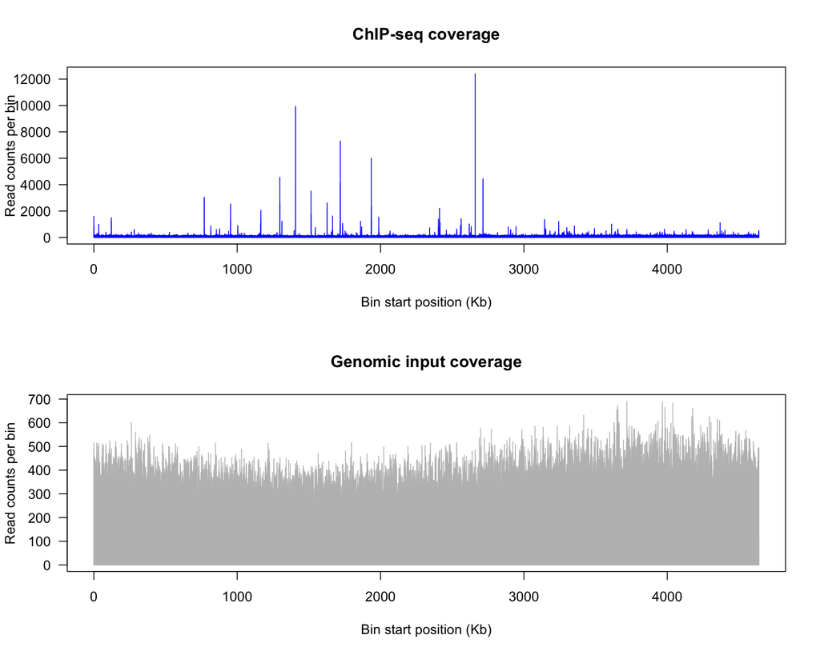

**Coverage profiles**.

```r
par(mfrow=c(2,1))
plot(x = chip.bedg$start/1000,
     y = chip.bedg$counts,
     main="ChIP-seq coverage",
     xlab="Bin start position (Kb)",
     #     cex=0.5,
     col="blue",
     type="h",
     las=1,
     ylab="Read counts per bin")

plot(x = input.bedg$start/1000,
     y = input.bedg$counts,
     main="Genomic input coverage",
     xlab="Bin start position (Kb)",
     #     cex=0.5,
     col="grey",
     type="h",
     las=1,
     ylab="Read counts per bin")
```

```r
par(mfrow=c(1,1))
```

### Interpretation of the coverage profiles

- The coverage profile of the ChIP-ped sample shows striking peaks at different genomic positions.
- The genomic input shows fluctuations, but no such peaks.
- Note that the scales are different: genomic input varies from 0 to 691, whereas the ChIP-seq peaks reach 12411.
[^1]: Tip: you can use the R `cumsum()` function.
[^2]: http://jvanheld.github.io/stats_avec_RStudio_EBA//practicals/02_peak-calling/data/FNR_200bp.bedg
[^3]: http://jvanheld.github.io/stats_avec_RStudio_EBA//practicals/02_peak-calling/data/input_200bp.bedg